# 확률통계

먼저 디지털 글쓰기를 쉽게 누구나 시작할 수 있습니다. 비밀은 마크다운 형식으로 글을 쓰며, R/파이썬 코드를 실행할 수 있고 수학도 가능합니다.

## 계산기

사칙연산은 기본입니다.

```r
2*3
```

```
## [1] 6
```

확률통계의 최고봉 정규분포에서 평균 0, 분산 1 표준정규분포로부터 표본 30개 추출은 기본입니다.

```r
samples <- rnorm(30)
samples
```

```
##  [1]  0.1769526531  1.0337996347  0.4563697934  1.4105660348 -0.0763950958
##  [6] -0.6465674251  0.3984092043 -1.3077313356 -0.2779914799 -0.7978332931
## [11] -0.1409512827 -0.3403983863  0.3795278106 -0.0647213349  0.7880295132
## [16] -1.4877932981 -0.2801391836 -0.1870086950 -0.3370176316 -2.5497274674
## [21] -0.2529189386 -0.0719579737 -0.4442187221  0.0009186909 -0.5626226451
## [26] -1.1659191978  1.2971531101 -0.0551442174 -1.3721238268  1.1773758750
```

## 그래프

더이상 엑셀에서 그래프를 그리고 복사하여 붙여넣기 할 필요가 없습니다. R 혹은 파이썬 코드 한두줄로 끝~~~

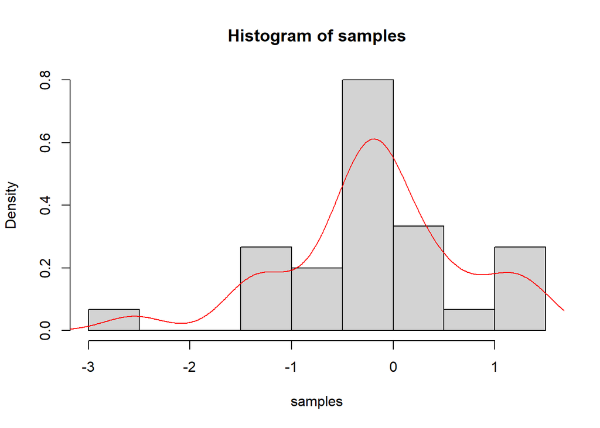

```r
hist(samples, prob = TRUE)
lines(density(samples), col = "red")
```

## 요약통계량

모집단에서 나온 수많은 데이터를 이해하는 요약통계량도 한두줄로 가능합니다.

```r
summary(samples)
```

```
##    Min. 1st Qu.  Median    Mean 3rd Qu.    Max.
## -2.5497 -0.5330 -0.1640 -0.1767  0.3289  1.4106
```

모집단을 파악하기 위해 30개 표본을 추출한 결과 중심을 나타내는 지표중 하나인 평균은 -0.1766693 이고, 표본의 퍼짐을 나타내는 지표중 하나인 분산은 0.7624779, 표준편차는 0.8731998 으로 조사되었습니다.

## 표

표본정규분포에서 나온 결과라서 이를 표를 통해 확인할 수 이 있습니다.

```r
## 표본수 증가 30 --> 1,000
samples <- rnorm(1000)
## 평균과 표준편차 계산
samples_sd <- sqrt(var(samples))
samples_mean <- mean(samples)

## 표본이 각각 +-5% 양쪽 한계를 벗어난 것인지 확인
inout_test <- samples > (samples_mean + 1.96 * samples_sd) | samples < (samples_mean - 1.96 * samples_sd)

test_output <- table(inout_test)
test_output
```

```
## inout_test
## FALSE  TRUE
##   947    53
```

상기 결과를 멋진 표로 스타일을 넣어 꾸며보자. 표본이 95% 이내 위치하게 되면 **정상**, 그렇지 않으면 **특이점**으로 구분하여 표로 작성해본다.

```r
names(test_output) <- c("정상", "특이점")
knitr::kable(test_output,
             col.names = c("구분", "빈도수"))
```

| 구분 | 빈도수 |
| --- | --- |
| 정상 | 947 |
| 특이점 | 53 |

## 활용

수능 등급을 매기는데 이론적 기반을 제공하는 것이 정규분포다.

| 백분위(상위) | 등급 |
| --- | --- |
| 0% ~ 4% | 1 |
| 4% ~ 11% | 2 |
| 11% ~ 23% | 3 |
| 23% ~ 40% | 4 |
| 40% ~ 60% | 5 |
| 60% ~ 77% | 6 |
| 77% ~ 89% | 7 |
| 89% ~ 96% | 8 |
| 96% ~ 100% | 9 |

# 마무리

이것이 진정한 **디지털 글쓰기** 입니다. 디지털 글쓰기 없이 더이상의 과학기술 발전은 위험할 수 있습니다.